```python
import numpy as np
import pandas as pd
import matplotlib.pyplot as plt
```

# LSTM 이해

`-` 논문 : A Review of Recurrent Neural Networks: LSTM Cells and Network Architectures (Yong Yu, 2019)

# lstm

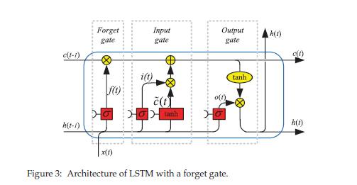

- 장기적 종속성 문제를 해결하기 위한 gate를 도입
- 흔히 lstm cell이란 것은 forget gate가 있는 lstm을 의미한다.
- $f(t)$ : forget gate는 정보의 삭제(0) or 유지(1)를 결정

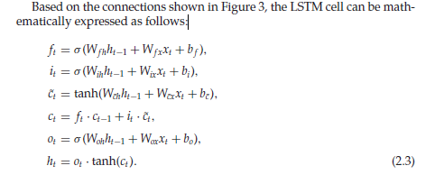

- 이러한 구조는 cell state가 직접적으로 lstm gate와 연결되있지 않아 성능이 좋지 못함
- 따라서 아래와 같이 peephole connection을 도입하여 LSTM 셀을 확장

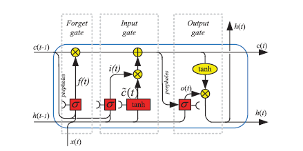

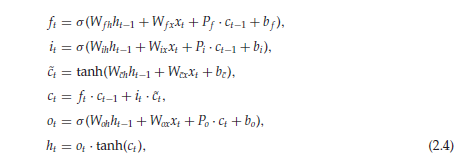

- cell state가 직접적으로 lstm cell에 연결된 것을 볼 수 있다.
- $P_f, P_i, P_o$는 각각 forget gate, input gate, output gate에 대한 peephole weights을 나타냄

# GRU

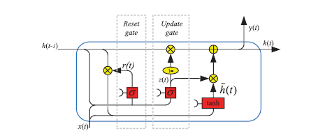

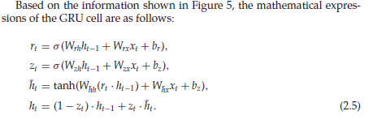

- GRU는 본질적으로 forget gate이 없는 일반적인 LSTM의 변형
- GRU 셀은 LSTM 셀의 forget gate와 input gate을 update gate로 통합하여 매개변수의 수를 줄dla
- GRU 셀은 오직 두 개의 게이트만을 가지고 있다. update gate와 reset gate

# Stacked LSTM Network

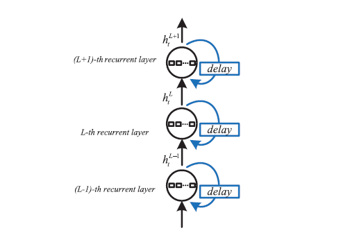

- .일반적으로 LSTM 레이어를 쌓아 올리는 것이 사용
- stacked LSTM 네트워크는 LSTM 네트워크의 가장 기본이자 간단한 구조
- 다층 완전 연결 구조

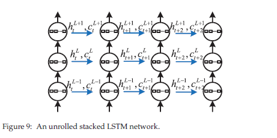

- 시간 차원에 따라서 도식을 펼침 시퀀스의 길이는 4
- t 시점에서 (L-1)번째 lstm 레이어의 출력은 $h_t^{L-1}$

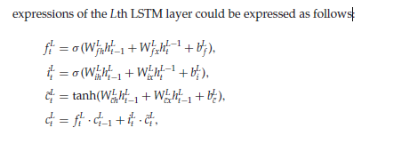

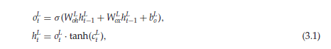